# Lista Normal Multivariada

Davi Wentrick Feijó

2023-06-25

### 55)

```r
rmvn.svd <-
  function(n, mu, Sigma) {
    p <- length(mu)
    S <- svd(Sigma)
    R <- S$u %*% diag(sqrt(S$d)) %*% t(S$v)
    Z <- matrix(rnorm(n*p), nrow=n, ncol=p)
    X <- Z %*% R + matrix(mu, n, p, byrow=TRUE)
    X
  }

n=100
mu <- c(3, 2)
Sigma <- matrix(c(1, -1.5, -1.5, 4),
                nrow = 2, ncol = 2)

results = rmvn.svd(n,mu,Sigma)
head(results)
```

```
##          [,1]       [,2]
## [1,] 4.127810  0.9705101
## [2,] 5.105565 -0.8712063
## [3,] 1.937415  4.0618086
## [4,] 3.744089  2.7016552
## [5,] 2.664212  3.4655523
## [6,] 2.669057  2.5891976
```

### 56)

Seja:
$$Z \sim N_P(0,I_p)$$
$$\sum_{i=1}^{p}Z_i^2 = Z^TZ \sim \chi^2_p$$
Mas

$$Z^TZ = (Y - \mu)^T(\Sigma^{1/2})^{-1}(\Sigma^{1/2})^{-1}(Y - \mu)$$
$$Z^TZ = (Y - \mu)^T\Sigma^{-1}(Y - \mu) \sim \chi^2_p$$

### 57)

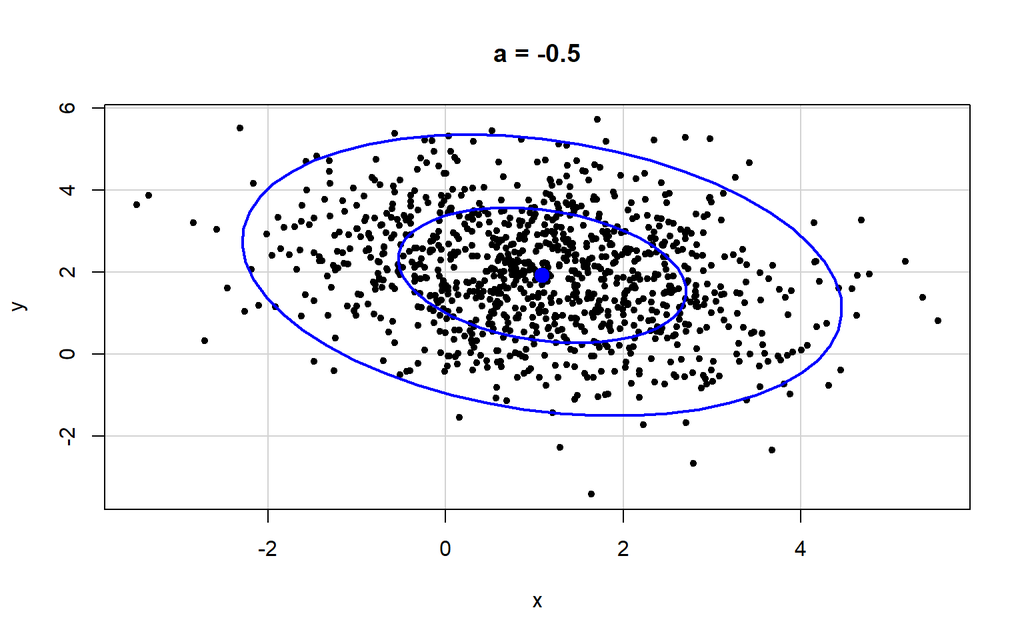

```r
a = -1/2
n=1000
mu <- c(1, 2)
Sigma <- matrix(c(2, a, a, 2),
                nrow = 2, ncol = 2)

r1 = rmvn.svd(n,mu,Sigma)


dataEllipse(r1,pch=20,
            main= "a = -0.5")
```

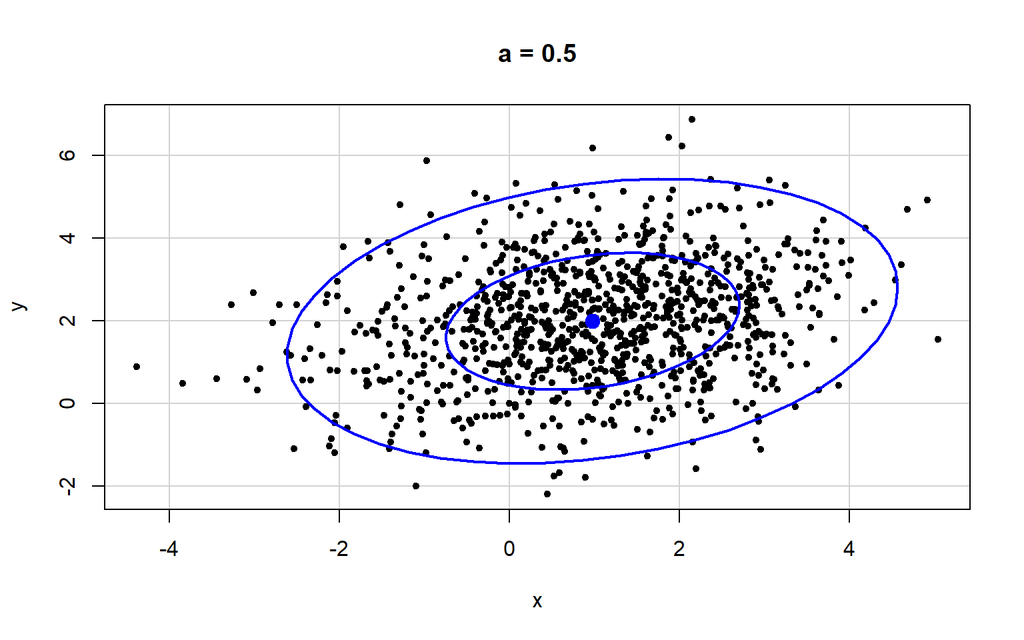

```r
a = 1/2
n=1000
mu <- c(1, 2)
Sigma <- matrix(c(2, a, a, 2),
                nrow = 2, ncol = 2)

r1 = rmvn.svd(n,mu,Sigma)


dataEllipse(r1,pch=20,
            main= "a = 0.5")
```

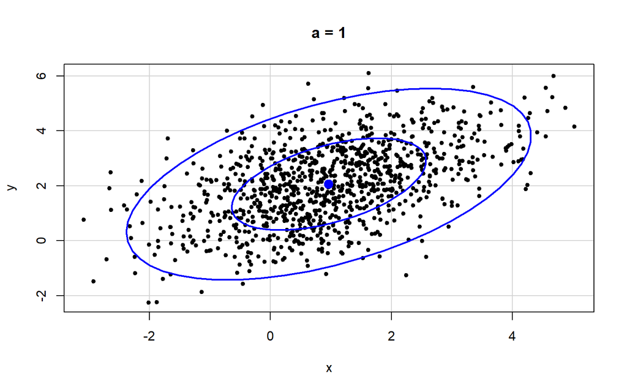

```r
a = 1
n=1000
mu <- c(1, 2)
Sigma <- matrix(c(2, a, a, 2),
                nrow = 2, ncol = 2)

r1 = rmvn.svd(n,mu,Sigma)


dataEllipse(r1,pch=20,
            main= "a = 1")
```

### 58)

$$A = [1,1] \ \ \ \ B = [1,-1]$$

$AY$ e $BY$ sao idependentes se:

$$A\Sigma B^T = 0$$

```r
mu <- c(2, 2)
Sigma <- matrix(c(1, 0, 0, 1),
                nrow = 2, ncol = 2)
a = c(1,1)
b = c(1,-1)

t(a) %*% Sigma %*% b #formual do slide nao funciona mas essa sim verificar
```

```
##      [,1]
## [1,]    0
```

```r
#acredito que o R por padrao use os vetores como coluna e nao linha, diferente da demonstracao do slide que assumimos que sao linhas
#logo temos que inverter e comecar com a transposta mas nao tenho certeza
```

### 59)

### 60) Johnson e Wichern - Exercício 4.26

Nossos dados do problema

```
##    x1    x2
## 1   1 18.95
## 2   2 19.00
## 3   3 17.95
## 4   3 15.54
## 5   4 14.00
## 6   5 12.95
## 7   6  8.94
## 8   8  7.49
## 9   9  6.00
## 10 11  3.99
```

Matriz de covariancia

```r
S = cov(dados)
S
```

```
##           x1        x2
## x1  10.62222 -17.71022
## x2 -17.71022  30.85437
```

#### a)

Para o calculo da distancia vamos usar a seguinte formula:

$$m^2_j = A S^{-1}A^T$$
Onde A é nosso vetor que contem a diferenca da observacao para a media:

$$A = [X_{j1};X_{j2}]-[\bar{X_1};\bar{X_2}] = [X_{j1} - \bar{X_1};X_{j2}-
\bar{X_2}]$$

```r
results = c()
for (i in c(1:10)){
  media = c(mean(x1),mean(x2))
  obs = c(x1[i],x2[i])
  m = t(obs-media) %*% solve(S) %*% (obs-media)
  results[i] = m
}

results
```

```
##  [1] 1.8753045 2.0203262 2.9009088 0.7352659 0.3105192 0.0176162 3.7329012
##  [8] 0.8165401 1.3753379 4.2152799
```

#### b)

Queremos as observacoes dentro do contorno de 50% da distribuicao normal. Sabemos que nesse caso a nossa distribuicao segue uma $\chi_2^2$ logo queremos as observacoes menores que $\chi_2^2(0.5)$ que podemos calcular usando o R:

```r
qchisq(0.5,2)
```

```
## [1] 1.386294
```

Filtrando nosso vetor de resultados temos:

```r
results[results < qchisq(0.5,2)]
```

```
## [1] 0.7352659 0.3105192 0.0176162 0.8165401 1.3753379
```

#### c)

Vamos ordenar as obsevacoes:

```r
obs_ordenadas = sort(results)
```

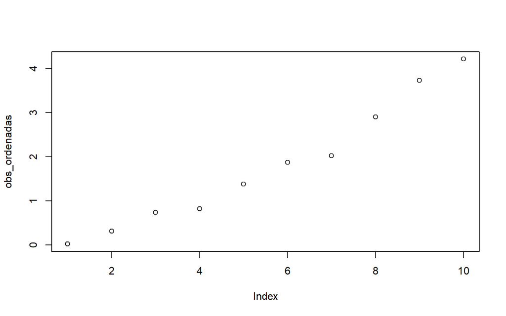

### 61) Johnson e Wichern - Exercício 4.27

```r
oven_number = c(1:42)
radiation = c(0.15,0.09,0.18,0.10,0.05,0.12,0.08,0.05,0.08,0.10,0.7,0.02,0.01,0.10,
              0.10,0.10,0.02,0.10,0.01,0.40,0.10,0.05,0.03,0.05,0.15,0.10,0.15,0.09,
              0.08,0.18,0.10,0.20,0.11,0.30,0.02,0.20,0.20,0.30,0.30,0.40,0.30,0.05)
dados = data.frame(oven_number,radiation)
```

```r
obs_ordenadas = sort(unique(radiation))
log_obs = log(obs_ordenadas)
```

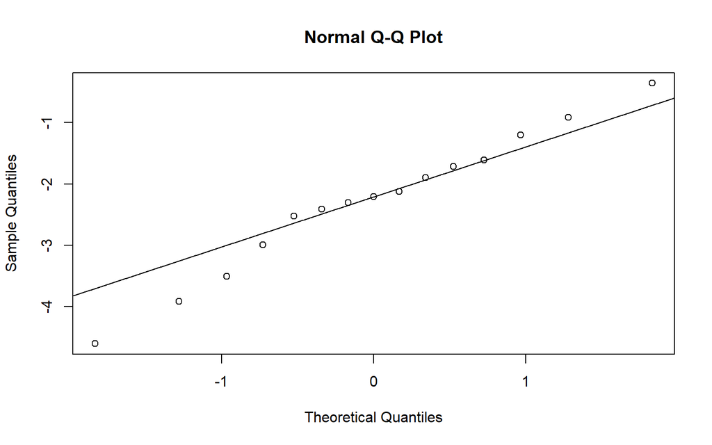

### 62) Johnson e Wichern - Exercício 4.35

### 63) Rencher e Christensen - Problema 4.1

```r
sigma1 <- matrix(c(14, 8, 3,
                    8, 5, 2,
                    3, 2, 1), nrow = 3)

sigma2 <- matrix(c(6, 6, 1,
                   6, 8, 2,
                   1, 2, 1), nrow = 3)
```

Vamos calcular a variancia total e generalizada para cada um dos Sigmas!

Sigma 1:

```r
var_tot = tr(sigma1)
var_gen = det(sigma1)
```

```
## A variancia total de Sigma 1 é: 20
```

```
## A variancia generalizada de Sigma 1 é: 1
```

Sigma 2:

```r
var_tot = tr(sigma2)
var_gen = det(sigma2)
```

```
## A variancia total de Sigma 1 é: 15
```

```
## A variancia generalizada de Sigma 1 é: 4
```

### 64) Rencher e Christensen - Problema 4.2

Com base nessa equacao:

$$z = (T^t)^{-1}(y-\mu)$$
Vale relembrar algumas propriedades da combinação linear $z = Ay + b$ (Rencher e Christensen - Pagina 81)

$$E(Ay + b) = AE(y) + b = A \mu + b$$

$$Cov(Ay + b) = A \Sigma A^t$$

vamos mostrar que: $E(Z) = 0$

$$E(z) = (T^t)^{-1}(E(y)-\mu)$$
$$E(z) = (T^t)^{-1}(\mu-\mu) = 0$$
$Cov(Z) = I$

$$Cov(Z) = (T^t)^{-1}\Sigma[(T^t)^{-1}]^t$$
Sabemos que $\Sigma = T^tT$

$$Cov(Z) = (T^t)^{-1}T^tTT^{-1} = I$$

### 65) Rencher e Christensen - Problema 4.10

#### a)

Vamos utlizar a propriedade de que se $a$ é um vetor de constantes e $Y \sim N_p(\mu,\Sigma)$ entao $A^TY \sim N_p(A^T\mu,A^T\Sigma A)$ (Rencher e Christensen - Pagina 94)

```r
mu <- c(3,1,4)
sigma <- matrix(c(6, 1, -2,
                  1, 13, 4,
                  -2, 4, 4), nrow = 3)
a = c(2,-1,3)

t(a) %*% mu
```

```
##      [,1]
## [1,]   17
```

```r
t(a) %*% sigma %*% a
```

```
##      [,1]
## [1,]   21
```

```
## A função segue distribuição: N( 17 , 21 )
```

#### b)

Primeiro temos que encontrar $Z_1$ e $Z_2$

```r
a =  matrix(c(1, 1, 1,
              1, -1, 2), ncol =3, nrow =2, byrow = T)

z_mu = a %*% mu

z_sigma = a %*% sigma %*% t(a)
```

```r
z_mu
```

```
##      [,1]
## [1,]    8
## [2,]   10
```

```r
z_sigma
```

```
##      [,1] [,2]
## [1,]   29   -1
## [2,]   -1    9
```

```
##  A distribuição conjunta segue distribuição: N( 8 10 , 29 -1 -1 9 )
```

#### c)

Se $Y \sim N_p(\mu,\Sigma)$ entao cada $y_j \sim N_p(\mu_j,\Sigma_{jj})$

```
## A y2 segue distribuição: N( 1 , 13 )
```

#### d)

A distribuição conjunta de $y_1$ e $y_3$ é:

```r
new_mu = c(mu[1],mu[3])
new_sigma <- matrix(c(sigma[1,1], sigma[3,1],
                      sigma[1,3], sigma[3,3]), nrow = 2)
```

Onde os parametros da distribuição conjunta é:

```
## Matriz de médias
```

```
## [1] 3 4
```

```
## Matriz Sigma
```

```
##      [,1] [,2]
## [1,]    6   -2
## [2,]   -2    4
```

#### e)

vamos montar nosso vetor A de acordo com a equacao dada:

```r
a =  matrix(c(1, 0, 0,
              0, 0, 1,
              0.5,0.5,0), ncol =3, nrow =2, byrow = T)
```

Matriz de médias

```r
a %*% mu
```

```
##      [,1]
## [1,]    3
## [2,]    4
```

Matriz de covariancia

```r
a %*% sigma %*% t(a)
```

```
##      [,1] [,2]
## [1,]    6   -2
## [2,]   -2    4
```

### 66) Rencher e Christensen - Problema 4.11

Essa é a equcao de padronizaçao da normal multivariada

$$z = (T^t)^{-1}(y-\mu)$$
#### a)

Sabemos que podemos decompor a matriz $\Sigma = T^tT$ por meio da decomposicao de cholesky (`chol()`)

```r
t = chol(sigma)
t
```

```
##         [,1]      [,2]       [,3]
## [1,] 2.44949 0.4082483 -0.8164966
## [2,] 0.00000 3.5823642  1.2096295
## [3,] 0.00000 0.0000000  1.3675269
```

Agora vamos calcular $(T^t)^{-1}$

```r
t(solve(t))
```

```
##             [,1]       [,2]     [,3]
## [1,]  0.40824829  0.0000000 0.000000
## [2,] -0.04652421  0.2791453 0.000000
## [3,]  0.28490144 -0.2469146 0.731247
```

Nosso vetor Z pode ser escrito como:

$$\begin{pmatrix}
0.41 & 0.00 & 0.00 \\
-0.05 & 0.28 & 0.00 \\
0.28 & -0.25 & 0.73 \\
\end{pmatrix}
\cdot
\begin{pmatrix}
y-3 \\
y-1 \\
y-4 \\
\end{pmatrix}$$

Podemos mostrar que ao calcular a matriz de covariancia por meio da formula $Cov(z) = (T^t)^{-1}T^tTT^{-1}$ tem que resultar na matriz identidade

```r
round(t(solve(t)) %*% t(t) %*% t %*% solve(t),1)
```

```
##      [,1] [,2] [,3]
## [1,]    1    0    0
## [2,]    0    1    0
## [3,]    0    0    1
```

#### b)

Vamos calcular $\Sigma^{1/2}$ e para isso vamos usar o `eigen()`. Ao realizar a decomposição precisamos somente tirar a raiz de D que é a matriz diagonal com os autovalores.

```r
eigen_sigma = eigen(sigma)

sigma_raiz_inv = eigen_sigma$vectors %*% solve(diag(eigen_sigma$values^(1/2))) %*% t(eigen_sigma$vectors)
```

```r
sigma_raiz_inv
```

```
##             [,1]        [,2]       [,3]
## [1,]  0.46496849 -0.06966936  0.1701484
## [2,] -0.06966936  0.32645938 -0.1657086
## [3,]  0.17014841 -0.16570861  0.6916013
```

$$\begin{pmatrix}
0.46 & -0.07 & 0.17 \\
-0.07 & 0.33 & -0.17 \\
0.17 & -0.17 & 0.69 \\
\end{pmatrix}
\cdot
\begin{pmatrix}
y-3 \\
y-1 \\
y-4 \\
\end{pmatrix}$$

#### c)

Ela segue uma distribuição qui-quadrado

$$(y - \mu)^t \Sigma^{-1} (y - \mu) \sim \chi^2_3$$

### 67) Rencher e Christensen - Problema 4.12

```r
mu <- c(-2,3,-1,5)
sigma <- matrix(c(11, -8, 3, 9,
                  -8,  9,-3,-6,
                   3, -3, 2, 3,
                   9, -6, 3, 9), nrow = 4)
```

#### a)

```r
a = c(4,-2,1,-3)

t(a) %*% mu
```

```
##      [,1]
## [1,]  -30
```

```r
t(a) %*% sigma %*% a
```

```
##      [,1]
## [1,]  153
```

#### b)

```r
a = matrix(c(1, 1, 1, 1,
            -2, 3, 1,-2),nrow = 2, byrow = TRUE)

a %*% mu
```

```
##      [,1]
## [1,]    5
## [2,]    2
```

```r
a %*% sigma %*% t(a)
```

```
##      [,1] [,2]
## [1,]   27  -79
## [2,]  -79  361
```

#### c)

```r
a = matrix(c(3, 1,-4,-1,
            -1, -3, 1,-2,
             2, 2, 4,-5),nrow = 3, byrow = TRUE)

a %*% mu
```

```
##      [,1]
## [1,]   -4
## [2,]  -18
## [3,]  -27
```

```r
a %*% sigma %*% t(a)
```

```
##      [,1] [,2] [,3]
## [1,]   35  -18   -6
## [2,]  -18   46   14
## [3,]   -6   14   93
```

#### d)

Se $Y \sim N_p(\mu,\Sigma)$ entao cada $y_j \sim N_p(\mu_j,\Sigma_{jj})$

```
## A y3 segue distribuição: N( -1 , 2 )
```

#### e)

A distribuição conjunta de $y_2$ e $y_4$ é:

```r
new_mu = c(mu[2],mu[4])
new_sigma <- matrix(c(sigma[2,2], sigma[4,2],
                      sigma[2,4], sigma[4,4]), nrow = 2)
```

```r
new_mu
```

```
## [1] 3 5
```

```r
new_sigma
```

```
##      [,1] [,2]
## [1,]    9   -6
## [2,]   -6    9
```

#### f)

```r
a = matrix(c(1, 1/2, 1/2, 0,
             1/3, 1/3, 1/3,0,
             1/4, 1/4, 1/4, 1/4),nrow = 3, byrow = TRUE)

a %*% mu
```

```
##               [,1]
## [1,] -1.000000e+00
## [2,]  5.551115e-17
## [3,]  1.250000e+00
```

```r
a %*% sigma %*% t(a)
```

```
##       [,1]      [,2]   [,3]
## [1,] 7.250 2.0000000 3.3750
## [2,] 2.000 0.6666667 1.0000
## [3,] 3.375 1.0000000 1.6875
```

### 68) Rencher e Christensen - Problema 4.13

#### a)

```r
t = chol(sigma)
t
```

```
##          [,1]      [,2]       [,3]      [,4]
## [1,] 3.316625 -2.412091  0.9045340 2.7136021
## [2,] 0.000000  1.783765 -0.4586825 0.3057883
## [3,] 0.000000  0.000000  0.9856108 0.6957252
## [4,] 0.000000  0.000000  0.0000000 1.0289915
```

Agora vamos calcular $(T^t)^{-1}$

```r
t(solve(t))
```

```
##             [,1]       [,2]       [,3]      [,4]
## [1,]  0.30151134  0.0000000  0.0000000 0.0000000
## [2,]  0.40771775  0.5606119  0.0000000 0.0000000
## [3,] -0.08696566  0.2608970  1.0145993 0.0000000
## [4,] -0.85749293 -0.3429972 -0.6859943 0.9718253
```

Nosso vetor Z pode ser escrito como:

$$\begin{pmatrix}
0.30 & 0.00 & 0.00 & 0.00 \\
0.41 & 0.56 & 0.00 & 0.00 \\
-0.09 & 0.26 & 1.01 & 0.00 \\
-0.86 & -0.34 & -0.69 & 0.97 \\
\end{pmatrix}
\cdot
\begin{pmatrix}
y+2 \\
y-3 \\
y+1 \\
y-5 \\
\end{pmatrix}$$

#### b)

Vamos calcular $\Sigma^{1/2}$ e para isso vamos usar o `eigen()`. Ao realizar a decomposição precisamos somente tirar a raiz de D que é a matriz diagonal com os autovalores.

```r
eigen_sigma = eigen(sigma)

sigma_raiz_inv = eigen_sigma$vectors %*% solve(diag(eigen_sigma$values^(1/2))) %*% t(eigen_sigma$vectors)
```

```r
sigma_raiz_inv
```

```
##            [,1]        [,2]       [,3]        [,4]
## [1,]  0.8103582  0.30518060  0.1433357 -0.47920688
## [2,]  0.3051806  0.58145299  0.2489169 -0.08256882
## [3,]  0.1433357  0.24891687  1.1527722 -0.29767675
## [4,] -0.4792069 -0.08256882 -0.2976767  0.78700454
```

$$\begin{pmatrix}
0.81 & 0.31 & 0.14 & -0.48 \\
0.31 & 0.58 & 0.25 & -0.08 \\
0.14 & 0.25 & 1.15 & -0.30 \\
-0.48 & -0.08 & -0.30 & 0.79 \\
\end{pmatrix}
\cdot
\begin{pmatrix}
y+2 \\
y-3 \\
y+1 \\
y-5 \\
\end{pmatrix}$$

#### c)

Ela segue uma distribuição qui-quadrado

$$(y - \mu)^t \Sigma^{-1} (y - \mu) \sim \chi^2_4$$

### 69) Rencher e Christensen - Problema 4.14

Para saber se é independente basta olhar os valores fora da diagonal da matris Sigma, ou seja se as covariancias sao iguais ou diferentes de 0

- 1. dependente
- 2. independente
- 3. independente
- 4. independente
- 5. dependente

### 70) Rencher e Christensen - Problema 4.17